# Communicate-Data-Finding-Exploration-with-Bike-Data

## Xi Zhou

- Introduction of the topic and dataset
- Dataset Investigation and preliminary wrangling
- Further Data Wrangling
- Univariate Exploration and Analysis
- Bivariate Exploration and Analysis
- Multivariate Exploration and Analysis
- Conclusions and answers

## Preliminary Wrangling

- I chose Ford GoBike System Data : https://www.fordgobike.com/system-data as my source data
- This data set includes information about individual rides made in a bike-sharing system covering the greater San Francisco Bay area.
- Multiple data files will need to be joined together if a full year’s coverage is desired.
- The features included in the dataset : Trip Duration (seconds) , Start Time and Date , End Time and Date , Start Station ID , Start Station Name , Start Station Latitude , Start Station Longitude , End Station ID , End Station Name, End Station Latitude , End Station Longitude , Bike ID , User Type (Subscriber or Customer – “Subscriber” = Member or “Customer” = Casual) , Member Year of Birth, Member Gender

```python
# import all packages and set plots to be embedded inline
import numpy as np
import pandas as pd
import matplotlib.pyplot as plt
import seaborn as sb
import os
import zipfile as zf
%matplotlib inline
```

> Load in your dataset and describe its properties through the questions below. Try and motivate your exploration goals through this section.

```python
# here source files seems like csv.zip but can actually be read in just like csv files
#zf = zipfile.ZipFile('C:/Users/Desktop/THEZIPFILE.zip')
#df = pd.read_csv(zf.open('intfile.csv'))
# do not need to unzip

# create the path and get the name list under the path
curDir = os.getcwd()
path = curDir+'/fordgobike/'
text_files = os.listdir(path)
#text_files

# build the frame df by appending each file
file_list = []
print ("reading data... ")
for text_file in text_files:
    #print(text_file)
    filename = path+text_file
    #print(filename)
    df = pd.read_csv(filename)
    file_list.append(df)
df_bike = pd.concat(file_list)


df_bike_copy =  df_bike.copy()
print(df_bike_copy.shape)
df_bike_copy
```

```
reading data...
(1863721, 16)
```

[output not shown]

1863721 rows × 16 columns

```python
# do some data cleaning : drop nan , remove some insignificant features like
df_bike_copy.drop(['start_station_latitude','start_station_longitude', 'end_station_latitude', 'end_station_longitude'], axis=1, inplace=True)
df_bike_copy.head()
```

|  | duration_sec | start_time | end_time | start_station_id | start_station_name | end_station_id | end_station_name | bike_id | user_type | member_birth_year | member_gender | bike_share_for_all_trip |
| --- | --- | --- | --- | --- | --- | --- | --- | --- | --- | --- | --- | --- |
| 0 | 75284 | 2018-01-31 22:52:35.2390 | 2018-02-01 19:47:19.8240 | 120.0 | Mission Dolores Park | 285.0 | Webster St at O'Farrell St | 2765 | Subscriber | 1986.0 | Male | No |
| 1 | 85422 | 2018-01-31 16:13:34.3510 | 2018-02-01 15:57:17.3100 | 15.0 | San Francisco Ferry Building (Harry Bridges Pl... | 15.0 | San Francisco Ferry Building (Harry Bridges Pl... | 2815 | Customer | NaN | NaN | No |
| 2 | 71576 | 2018-01-31 14:23:55.8890 | 2018-02-01 10:16:52.1160 | 304.0 | Jackson St at 5th St | 296.0 | 5th St at Virginia St | 3039 | Customer | 1996.0 | Male | No |
| 3 | 61076 | 2018-01-31 14:53:23.5620 | 2018-02-01 07:51:20.5000 | 75.0 | Market St at Franklin St | 47.0 | 4th St at Harrison St | 321 | Customer | NaN | NaN | No |
| 4 | 39966 | 2018-01-31 19:52:24.6670 | 2018-02-01 06:58:31.0530 | 74.0 | Laguna St at Hayes St | 19.0 | Post St at Kearny St | 617 | Subscriber | 1991.0 | Male | No |

```python
df_bike_copy.isnull().sum()
```

```
duration_sec                    0
start_time                      0
end_time                        0
start_station_id            11771
start_station_name          11771
end_station_id              11771
end_station_name            11771
bike_id                         0
user_type                       0
member_birth_year          110718
member_gender              110367
bike_share_for_all_trip         0
dtype: int64
```

```python
df_bike_copy.shape
```

```
(1863721, 12)
```

### What is the structure of your dataset?

The data set includes multiple csv files(12 months) with 1863721 rows and 12 features

### What is/are the main feature(s) of interest in your dataset?

1. How long does the average trip take?
2. Is the trip duration affected by weather( months/seasons)
3. Does the above depend on if a user is a subscriber or customer?

### What features in the dataset do you think will help support your investigation into your feature(s) of interest?

> Trip Duration (seconds), Start Time and Date , End Time and Date, User Type , Member Year of Birth , Member Gender

## Univariate Exploration

> In this section, investigate distributions of individual variables. If you see unusual points or outliers, take a deeper look to clean things up and prepare yourself to look at relationships between variables.

Question 1 : I want to know is " How long does the average trip take?"

```
Text(0.5,0,'duration_sec')
```

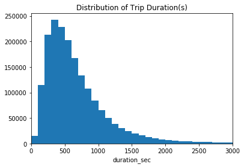

```python
# Let's plot the distribution of trip duration.
bin_edges = np.arange(0, df_bike_copy['duration_sec'].max() + 100 , 100)
plt.hist(data = df_bike_copy , x = 'duration_sec' , bins = bin_edges)
plt.xlim(0,3000)
plt.title('Distribution of Trip Duration(s)')
plt.xlabel('duration_sec')
```

### Discuss the distribution(s) of your variable(s) of interest. Were there any unusual points? Did you need to perform any transformations?

> Yes,It is right screwed with a long tail on the right. I am going to add log transformation to x axis.

### Of the features you investigated, were there any unusual distributions? Did you perform any operations on the data to tidy, adjust, or change the form of the data? If so, why did you do this?

> It is really difficult to look at the plot. I had to increase the bin width to 100 to let the plot show. Measuring trip using seconds is not reasonable. I would change the "duration_sec" to "duration_min" before I add any log transformation .

```
Text(0,0.5,'Frequency')
```

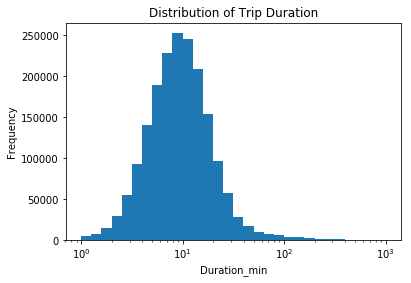

```python
# change the trip duration unit from second to min
df_bike_copy['duration_min'] = df_bike_copy['duration_sec'] / 60
df_bike_copy.drop('duration_sec' , axis = 1 , inplace = True)

bin_edges = 10**np.arange(0 , 3+0.1 , 0.1)
ticks =  [ 0.1 , 0.3 , 1 , 3, 10, 30, 100, 300]
labels = ['{}'.format(v) for v in ticks]
plt.hist(data = df_bike_copy , x = 'duration_min' , bins = bin_edges);
plt.xticks(ticks,labels);
plt.xlabel('Duration_min');
plt.xscale('log');
plt.title('Distribution of Trip Duration')
plt.ylabel('Frequency')
```

we can see through the plot, most people tend to use the bikes for short-time trips ( around 10 mins). Does weather affect the trip duration ? ( compare trip duration difference of spring, summer autumn, winter )

## Bivariate Exploration

> In this section, investigate relationships between pairs of variables in your data. Make sure the variables that you cover here have been introduced in some fashion in the previous section (univariate exploration).

```python
# some data engineering should be conducted:
# create month_start and month_end columns by extracting months of start_time and end_time

df_bike_copy['month_start'] = pd.DatetimeIndex(df_bike_copy['start_time']).month
df_bike_copy['day_start'] = pd.DatetimeIndex(df_bike_copy['start_time']).day
df_bike_copy.head()
df_bike_copy['month_start'].value_counts()


#method 2 to extract year, month, date
#df['start_time'] = pd.to_datetime(df['start_time'])

#df['start_year'] = df['start_time'].dt.year
#df['start_month'] = df['start_time'].dt.month
#df['start_day'] = df['start_time'].dt.day
```

```
10    201458
7     199222
6     195968
8     192162
9     186217
5     179125
11    134135
12    131363
4     131169
3     111382
2     106718
1      94802
Name: month_start, dtype: int64
```

Question 2. Does weather(month) affect the trip duration ?

```
Text(0,0.5,'Trip Duration(min)')
```

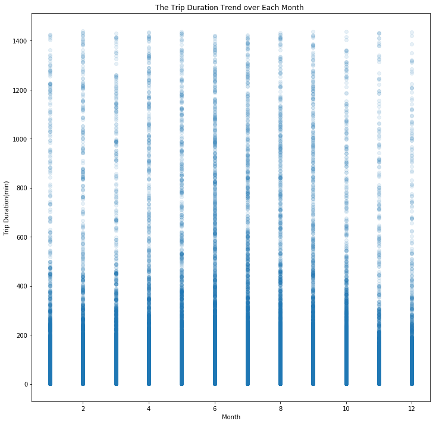

```python
# We can check the trip duration over changes over each month.
plt.figure(figsize = [12,12]) # make the whole figure bigger to show all
plt.scatter(data = df_bike_copy , x = 'month_start' , y = 'duration_min' , alpha = 0.1 )
plt.title('The Trip Duration Trend over Each Month ')
plt.xlabel('Month')
plt.ylabel('Trip Duration(min)')
```

June to Auguts in 2018 has the most duration. Other seasons do not have significant difference.

Will weather(season) show a more obvious affect on trip duration ?

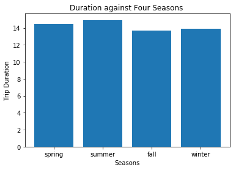

```python
# Create 4 season categories

spring_dur = df_bike_copy.query('month_start in ["3" , "4" , "5"]' ).duration_min.mean ()
summer_dur = df_bike_copy.query('month_start in ["6" , "7" , "8"] ').duration_min.mean()
fall_dur = df_bike_copy.query('month_start in ["9" , "10" , "11"] ').duration_min.mean()
winter_dur = df_bike_copy.query('month_start in ["12" , "1" , "2"]' ).duration_min.mean()
# here the month must be double quote characters, otherwise, give me systax errors


plt.bar(['spring','summer','fall','winter'],[spring_dur , summer_dur , fall_dur , winter_dur] )
plt.title('Duration against Four Seasons ')
plt.xlabel('Seasons')
plt.ylabel('Trip Duration');
```

```python
spring_dur , summer_dur , fall_dur , winter_dur
```

```
(14.478559960728145, 14.92883296558112, 13.663165967178344, 13.897462371664115)
```

- As we expected, summer has the longest trip duration , with average above 14 mins.
- But there is no significant difference of trip duration in terms of four seasons. It is probably because the weather in San Francisco bay area does not change that much.
- What surprised me the most is fall has the lowest trip duration in 2018. Fall is most likely to experience good weather with pleasant average temperatures in SF. People are more likely to go out and exercise .
- After checking the news, it is likely caused by Wildfires in Northern California(11/9/2018) which lead to the worst air quality in SF for months.